# Projekt - metody pozyskiwania i wizualizacji danych

Patryk Marek

2022-05-15

# Temat i założenia projektu

Tematem projketu jest pobranie oraz wizualizacja danych przedstawiająca rozegrae gry e-sportowe w [League of Legends](https://www.leagueoflegends.com/pl-pl/) przez wybrane drużyny z regionu europejskiego w sezonie jedenastym (2021).

Przedstawione będą dane gier dla drużyn:

- MAD
- RGE
- G2
- FNC

Każda tabela będzie odnosiła się do danej drużyny i zawierała następujące dane: wynik meczu, punktacja, eliminacje, złoto, wieże, smoki, przeciwnik w danym meczu, eliminacje przeciwnika, złoto przeciwnika, wieże przeciwnika, smoki przeciwnika, czas gry, etap, turniej.

# MAD Lions

MAD Lions to hiszpańska drużyna założona pod koniec 2019 roku, wcześniej znana jako Splyce (założona w 2015 r.). Po sezonie dziesiątym który przeznaczyli na zgranie się członków zespołu zdominowali sezon jedenasty na europejskiej scenie zajmując pierwsze miejsce w obu splitach (wiosennym i letnim). Aktulnie pula wszystkich zdobytych nagród wynosi 141,813$ i 210,000€.

Przykładowe rozgrywki

| Result | Score | MAD Lions Kills | MAD Lions Golds | MAD Lions Towers | MAD Lions Dragons | Vs | Oponent Kills | Oponent Golds | Oponent Towers | Oponent Dragons | Duration | Week | Tournament |
| --- | --- | --- | --- | --- | --- | --- | --- | --- | --- | --- | --- | --- | --- |
| LOSS | 0-3 | 19 | 67.7 | 5 | 1 | DK | 32 | 77.6 | 8 | 4 | 39:33 | QUARTERFINALS | World Championship 2021 |
| LOSS | \| | 20 | 63.8 | 5 | 4 | DK | 22 | 67.6 | 9 | 1 | 35:49 | QUARTERFINALS | World Championship 2021 |
| LOSS | \| | 3 | 47.3 | 4 | 0 | DK | 16 | 57.9 | 11 | 3 | 29:06 | QUARTERFINALS | World Championship 2021 |
| LOSS | 0-1 | 13 | 78.0 | 5 | 2 | GEN | 24 | 87.6 | 9 | 5 | 48:08 | TIEBREAKERS | World Championship 2021 |
| WIN | 1-0 | 23 | 84.9 | 9 | 2 | LNG | 19 | 78.9 | 7 | 4 | 46:13 | TIEBREAKERS | World Championship 2021 |
| WIN | 1-0 | 17 | 64.4 | 11 | 2 | LNG | 7 | 51.6 | 2 | 2 | 31:22 | DAY7 | World Championship 2021 |
| WIN | 1-0 | 15 | 73.2 | 9 | 3 | TL | 10 | 62.5 | 4 | 2 | 37:14 | DAY7 | World Championship 2021 |
| LOSS | 0-1 | 12 | 70.4 | 7 | 1 | GEN | 18 | 75.5 | 8 | 4 | 39:45 | DAY7 | World Championship 2021 |
| LOSS | 0-1 | 6 | 43.0 | 3 | 0 | LNG | 21 | 51.3 | 7 | 3 | 26:27 | DAY3 | World Championship 2021 |
| WIN | 1-0 | 30 | 90.4 | 11 | 4 | GEN | 19 | 80.7 | 5 | 3 | 46:59 | DAY2 | World Championship 2021 |

Znacznie ciekawiej prezentuje się jednak tabela ze środnią zdobywanych celów w zależnościu o wyniku spotkania.

Średnie wartości

| Result | Matches | MAD Lions Avg kills | MAD Lions Avg golds | MAD Lions Avg towers | MAD Lions Avg dragons | Oponent Avg vs kills | Oponent Avg vs golds | Oponent Avg vs towers | Oponent Avg vs dragons |
| --- | --- | --- | --- | --- | --- | --- | --- | --- | --- |
| LOSS | 36 | 9.6 | 55.4 | 3.8 | 1.4 | 20 | 64.4 | 9.3 | 3.1 |
| WIN | 56 | 20.1 | 64.8 | 9.7 | 2.9 | 11 | 55.0 | 3.4 | 1.6 |

| Result | Kills diff. | Golds diff. | Towers diff. | Dragons diff. |
| --- | --- | --- | --- | --- |
| LOSS | -1.4 | 0.4 | 0.4 | -0.2 |
| WIN | 0.1 | 0.4 | 0.4 | -0.2 |

Wyliczone ze średnich wartości

### Wykresy

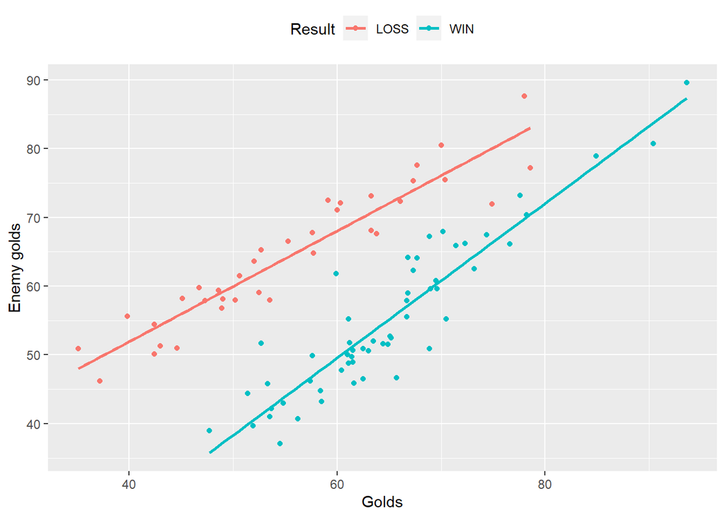

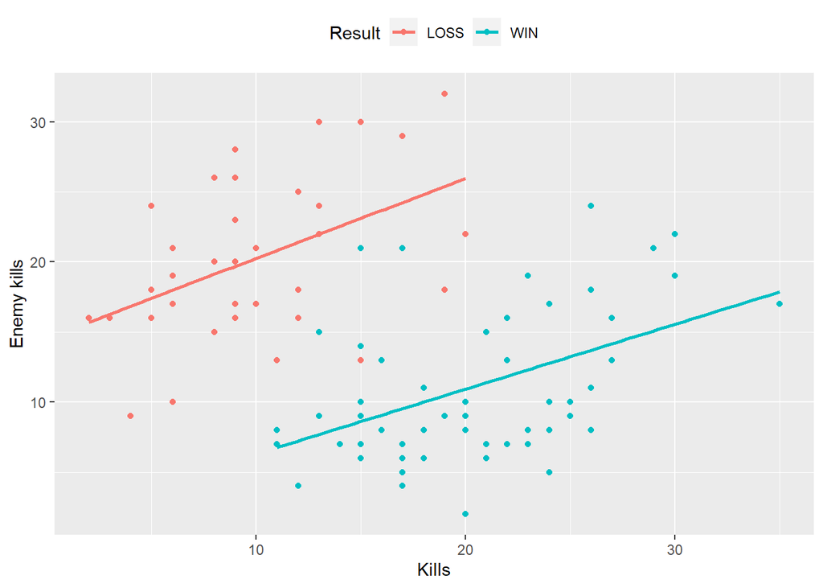

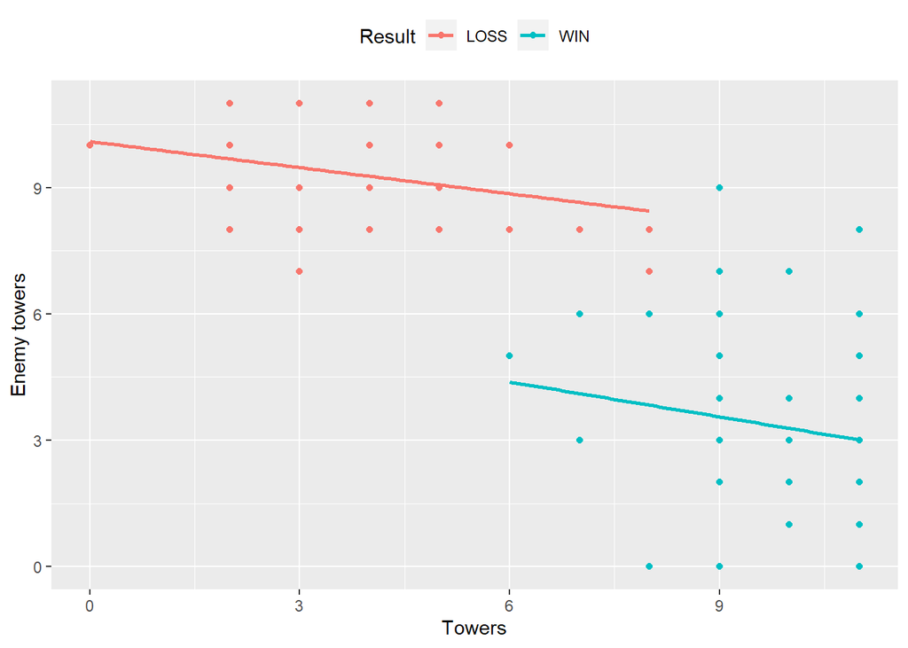

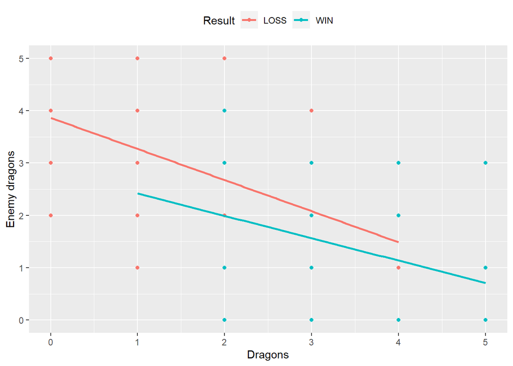

Powyżej przedstawione są cztery wykresy rozrzutu głównych celów gry pomiędzy MAD Lions a drużyną przeciwną.

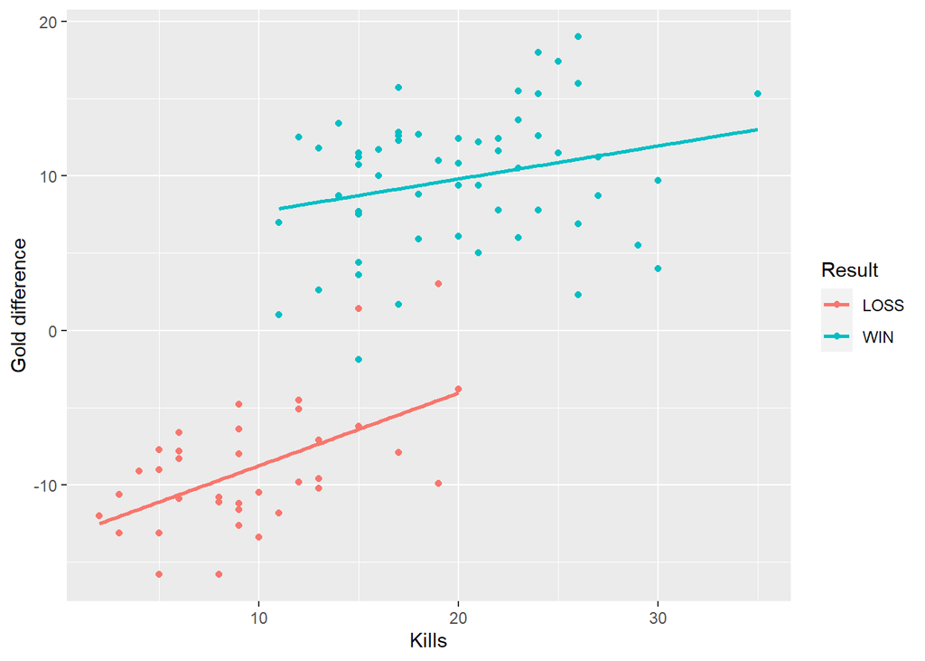

Na powyższym wykresie zilustrowna jest zależność pomiędzy zdobytymi eliminacjami a różnicą w złocie pomiędzy drużynami. Z krzształtu krzywych regresji widać że w przypadku przewagi złota dla przeciwnika hiszpańska drużyna jest w stanie wykorzystać eliminacje w znacznie bardziej efektywny sposób.

# Rogue

Jest to amerykańska drużyna założona założona w 2016 roku. Oddział europejski w League of Legends uformowany został dopiero w 2018 roku żeby dołączyć do oficjalnych rozgrywek regionalnych rok później. W naszym kraju jest to drużyna dosyć popularna ze względu na to że od 2019 w składzie pojawiło się aż sześciu graczy z Polski. Aktualnie pula zdobytych nagród wynosi 89,000$ i 142,500€.

Przykładowe rozgrywki

| Result | Score | Rouge Kills | Rouge Golds | Rouge Towers | Rouge Dragons | Vs | Oponent Kills | Oponent Golds | Oponent Towers | Oponent Dragons | Duration | Week | Tournament |
| --- | --- | --- | --- | --- | --- | --- | --- | --- | --- | --- | --- | --- | --- |
| LOSS | 0-1 | 15 | 91.4 | 5 | 3 | C9 | 17 | 97.8 | 11 | 4 | 54:07 | TIEBREAKERS | World Championship 2021 |
| WIN | 1-0 | 22 | 68.5 | 11 | 3 | FPX | 8 | 58.6 | 6 | 0 | 34:02 | TIEBREAKERS | World Championship 2021 |
| WIN | 1-0 | 21 | 75.5 | 10 | 3 | FPX | 14 | 69.0 | 5 | 2 | 40:57 | DAY4 | World Championship 2021 |
| LOSS | 0-1 | 11 | 60.9 | 3 | 2 | DK | 19 | 74.1 | 10 | 4 | 37:29 | DAY4 | World Championship 2021 |
| LOSS | 0-1 | 8 | 41.9 | 1 | 0 | C9 | 17 | 54.1 | 9 | 2 | 25:23 | DAY4 | World Championship 2021 |
| LOSS | 0-1 | 5 | 53.0 | 2 | 1 | FPX | 18 | 64.7 | 9 | 4 | 34:25 | DAY3 | World Championship 2021 |
| LOSS | 0-1 | 9 | 61.4 | 4 | 0 | DK | 15 | 69.2 | 8 | 5 | 37:03 | DAY2 | World Championship 2021 |
| WIN | 1-0 | 16 | 65.0 | 10 | 2 | C9 | 8 | 51.8 | 1 | 1 | 32:34 | DAY1 | World Championship 2021 |
| LOSS | 0-3 | 8 | 42.6 | 2 | 0 | FNC | 22 | 52.5 | 8 | 4 | 25:47 | SEMIFINALS | LEC Summer Playoffs 2021 |
| LOSS | \| | 16 | 52.2 | 4 | 1 | FNC | 25 | 60.6 | 9 | 3 | 30:12 | SEMIFINALS | LEC Summer Playoffs 2021 |

Średnie wartości

| Result | Matches | Rogue Avg kills | Rogue Avg golds | Rogue Avg towers | Rogue Avg dragons | Oponent Avg vs kills | Oponent Avg vs golds | Oponent Avg vs towers | Oponent Avg vs dragons |
| --- | --- | --- | --- | --- | --- | --- | --- | --- | --- |
| LOSS | 30 | 10.6 | 58.4 | 3.6 | 1.5 | 19.1 | 67.1 | 9.0 | 3.3 |
| WIN | 42 | 17.8 | 63.6 | 9.4 | 2.8 | 7.7 | 53.0 | 2.9 | 1.5 |

| Result | Kills diff. | Golds diff. | Towers diff. | Dragons diff. |
| --- | --- | --- | --- | --- |
| LOSS | 2.9 | 5.4 | 0.7 | 0.0 |
| WIN | -1.3 | -3.5 | 0.4 | -0.5 |

Wyliczone ze średnich wartości

Z powyższych tabel możemy zaobserwować że RGE radzi sobie znacznie lepiej od przeciwników kiedy są postawieni w pozycji przegrywającej (różnica aż 5.4 tysiąca złota) lecz nie potrafią zbudować znaczącej przewagi podczas zwycięstw (średnio niższe wartości od przeciwników w trzech z czterech głównych celów).

### Wykresy

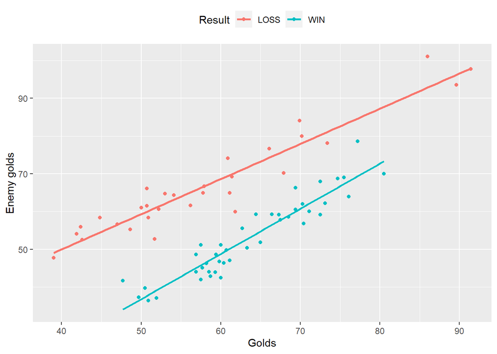

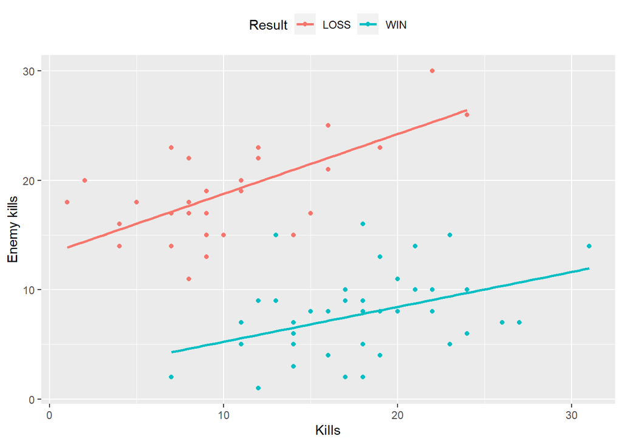

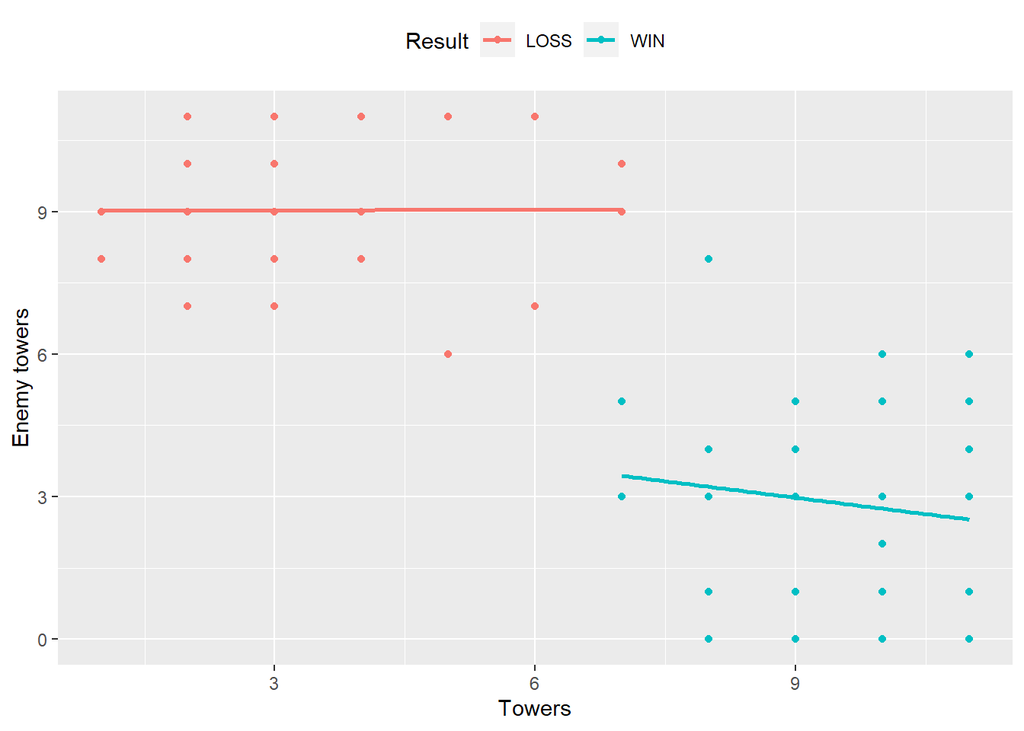

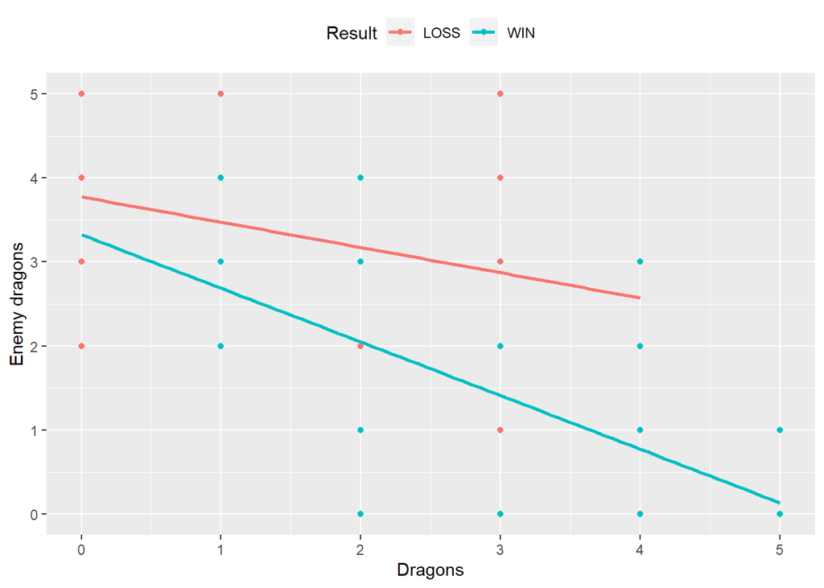

Powyżej przedstawione są cztery wykresy rozrzutu głównych celów gry pomiędzy Rouge a drużyną przeciwną.

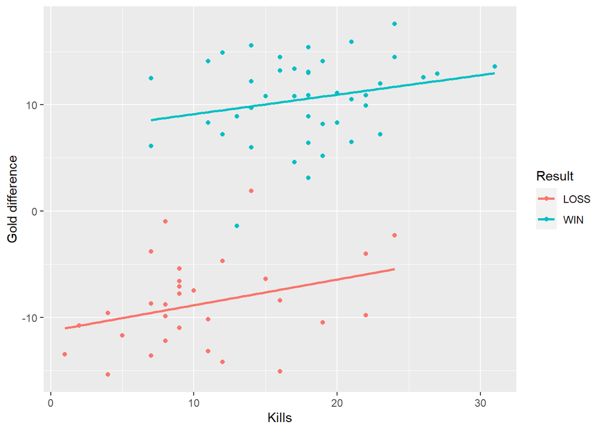

Z powyższego wykresu widać że ilość eliminacji ma podobny wpływ na wielkość różnicy w złocie w przypadku gier przegranych jak i wygranych.

# G2 Esports

G2 Esports to niemiecka drużyna założona w 2015 roku i aktywnie biorąca udział w rozgrywkach regionalnych od roku 2016. Aktualnie posiada status jednej z najmocniejszych dużyn w Europie, przyczyniły się do tego między innymi Mistrzostwa Świata 2019 kiedy to G2 przegrało dopiero finalny pojedynek z Chińską drużyną. Wpływ drużyny na region dostrzegli też inwestorzy, największymi partnerami G2 są: Twitch, Logitech, Adidas, BMW. Drużyna zebrała łącznie nagrody o wartości 2,026,307$ i 590,000€

Przykładowe rozgrywki

| Result | Score | G2 Esports Kills | G2 Esports Golds | G2 Esports Towers | G2 Esports Dragons | Vs | Oponent Kills | Oponent Golds | Oponent Towers | Oponent Dragons | Duration | Week | Tournament |
| --- | --- | --- | --- | --- | --- | --- | --- | --- | --- | --- | --- | --- | --- |
| LOSS | 2-3 | 5 | 42.7 | 3 | 1 | FNC | 21 | 53.7 | 9 | 3 | 27:04 | ROUND3 | LEC Summer Playoffs 2021 |
| LOSS | \| | 5 | 36.5 | 1 | 1 | FNC | 18 | 54.8 | 11 | 2 | 23:41 | ROUND3 | LEC Summer Playoffs 2021 |
| WIN | \| | 22 | 69.8 | 11 | 3 | FNC | 18 | 65.3 | 4 | 2 | 35:11 | ROUND3 | LEC Summer Playoffs 2021 |
| LOSS | \| | 6 | 44.6 | 1 | 1 | FNC | 23 | 59.5 | 10 | 3 | 28:56 | ROUND3 | LEC Summer Playoffs 2021 |
| WIN | \| | 18 | 62.5 | 10 | 1 | FNC | 10 | 54.2 | 4 | 3 | 31:55 | ROUND3 | LEC Summer Playoffs 2021 |
| LOSS | 1-3 | 6 | 48.8 | 2 | 3 | MAD | 17 | 61.1 | 11 | 1 | 30:30 | ROUND1 | LEC Summer Playoffs 2021 |
| LOSS | \| | 21 | 67.2 | 5 | 4 | MAD | 17 | 68.9 | 9 | 2 | 37:09 | ROUND1 | LEC Summer Playoffs 2021 |
| LOSS | \| | 9 | 45.8 | 3 | 1 | MAD | 15 | 53.3 | 9 | 2 | 26:59 | ROUND1 | LEC Summer Playoffs 2021 |
| WIN | \| | 16 | 54.4 | 9 | 4 | MAD | 2 | 42.4 | 2 | 0 | 28:09 | ROUND1 | LEC Summer Playoffs 2021 |
| WIN | 1-0 | 16 | 59.7 | 8 | 3 | XL | 5 | 47.5 | 2 | 0 | 30:58 | WEEK8 | LEC Summer 2021 |

Średnie wartości

| Result | Matches | G2 Esports Avg kills | G2 Esports Avg golds | G2 Esports Avg towers | G2 Esports Avg dragons | Oponent Avg vs kills | Oponent Avg vs golds | Oponent Avg vs towers | Oponent Avg vs dragons |
| --- | --- | --- | --- | --- | --- | --- | --- | --- | --- |
| LOSS | 30 | 8.7 | 52.1 | 3.0 | 1.7 | 18.1 | 61.5 | 9.2 | 2.8 |
| WIN | 42 | 19.8 | 66.0 | 9.5 | 3.4 | 10.6 | 55.7 | 2.8 | 1.2 |

| Result | Kills diff. | Golds diff. | Towers diff. | Dragons diff. |
| --- | --- | --- | --- | --- |
| LOSS | -1.9 | -3.6 | 0.2 | 0.5 |
| WIN | 1.7 | 4.5 | 0.3 | 0.6 |

Wyliczone ze średnich wartości

### Wykresy

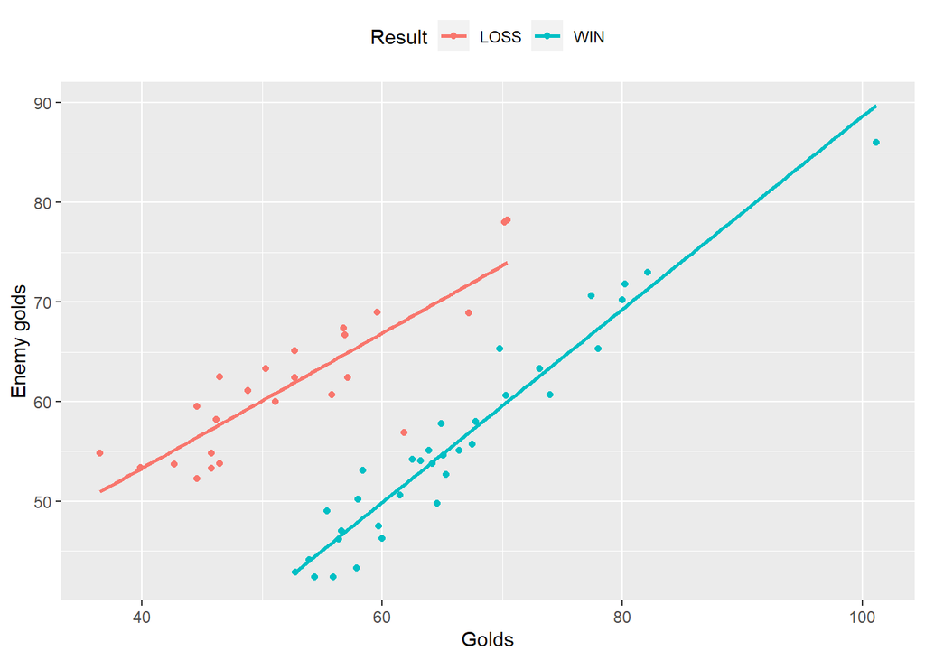

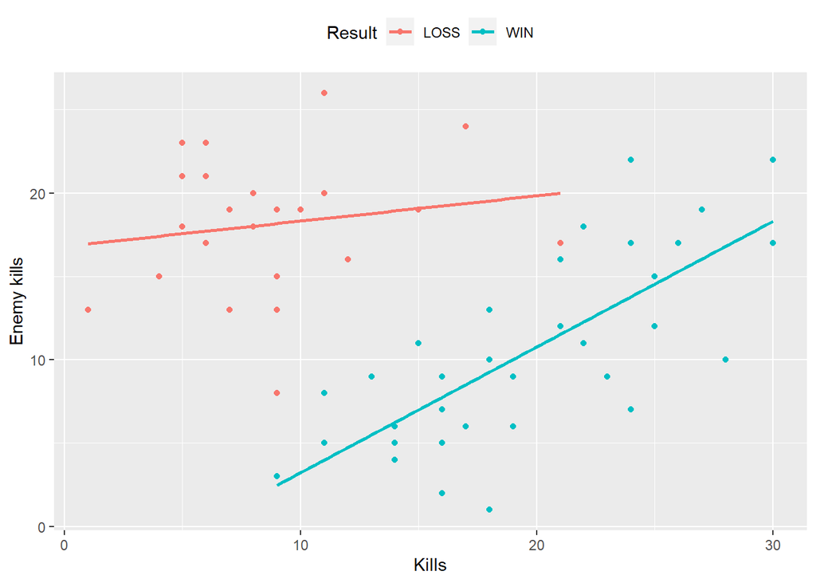

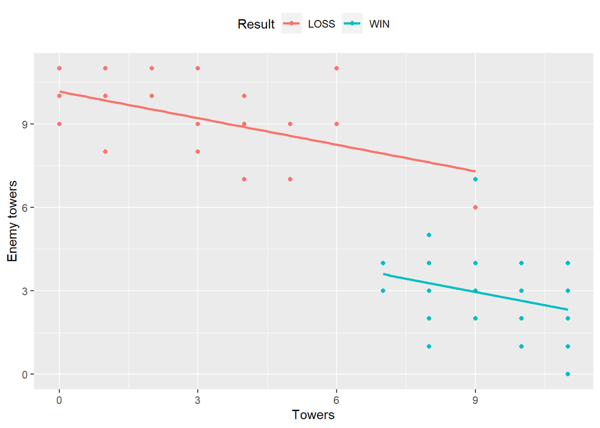

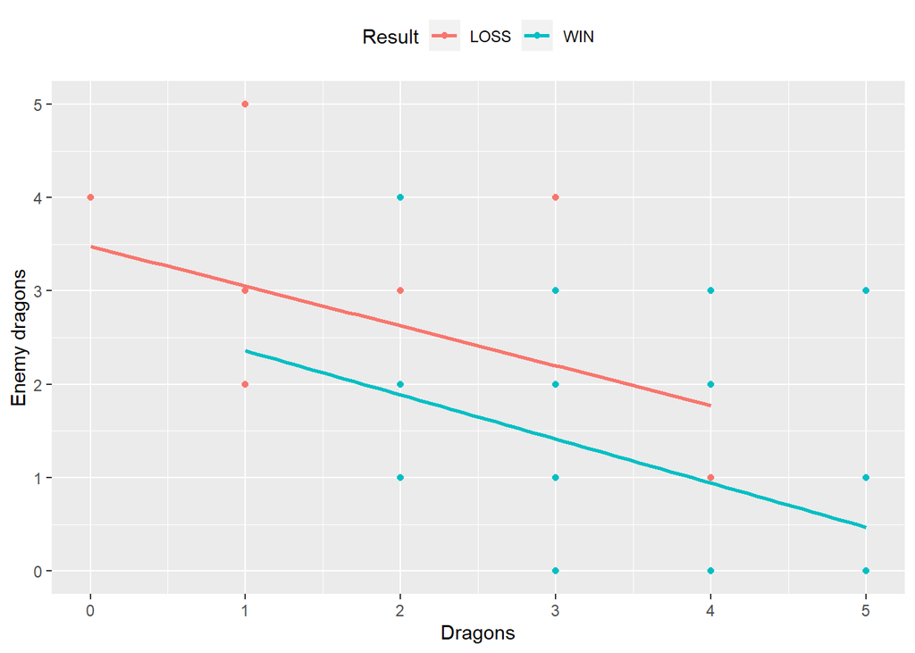

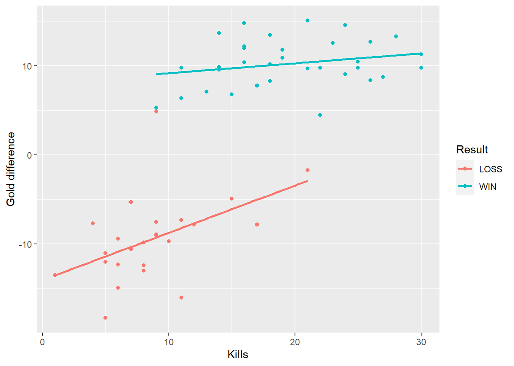

# Fnatic

Fnatic to drużyna założona w Anglii w roku 2011 co czyni ją jedną z najstarszych drużyn esportowych w League of Legends. W profesjonalnych rozgrywkach bierze udział już od sezonu pierwszego i jako jedyna drużna z Europy może poszczycić się zdobyciem mistrzostwa świata (Season 1 World Championship). Swoją pozycję ugruntowali także patronatem sponsorów takich jak BMW lub AMD oraz pulą nagród w wysokości USD 2,308,743, EUR 478,500, KRW 4,500,000, SEK 195,000 (Łącznie kwota ta wynosi 2,78 mln USD)

Przykładowe rozgrywki

| Result | Score | Fnatic Kills | Fnatic Golds | Fnatic Towers | Fnatic Dragons | Vs | Oponent Kills | Oponent Golds | Oponent Towers | Oponent Dragons | Duration | Week | Tournament |
| --- | --- | --- | --- | --- | --- | --- | --- | --- | --- | --- | --- | --- | --- |
| LOSS | 0-1 | 15 | 63.4 | 4 | 1 | PSG | 33 | 76.2 | 11 | 4 | 36:36 | DAY6 | World Championship 2021 |
| LOSS | 0-1 | 23 | 74.8 | 4 | 2 | HLE | 27 | 80.5 | 11 | 4 | 43:15 | DAY6 | World Championship 2021 |
| WIN | 1-0 | 26 | 75.3 | 10 | 4 | RNG | 28 | 66.7 | 5 | 2 | 37:31 | DAY6 | World Championship 2021 |
| LOSS | 0-1 | 12 | 80.6 | 6 | 4 | PSG | 20 | 84.0 | 8 | 3 | 46:11 | DAY3 | World Championship 2021 |
| LOSS | 0-1 | 13 | 53.8 | 3 | 1 | RNG | 34 | 67.6 | 10 | 2 | 30:50 | DAY2 | World Championship 2021 |
| LOSS | 0-1 | 5 | 50.0 | 2 | 1 | HLE | 25 | 65.6 | 9 | 3 | 31:42 | DAY1 | World Championship 2021 |
| LOSS | 1-3 | 8 | 46.7 | 1 | 2 | MAD | 26 | 65.7 | 10 | 2 | 30:57 | FINALS | LEC Summer Playoffs 2021 |
| LOSS | \| | 10 | 50.9 | 2 | 2 | MAD | 24 | 68.9 | 9 | 3 | 33:02 | FINALS | LEC Summer Playoffs 2021 |
| WIN | \| | 30 | 67.8 | 9 | 3 | MAD | 13 | 57.6 | 4 | 2 | 32:06 | FINALS | LEC Summer Playoffs 2021 |
| LOSS | \| | 16 | 60.8 | 2 | 2 | MAD | 27 | 69.5 | 9 | 4 | 35:22 | FINALS | LEC Summer Playoffs 2021 |

Średnie wartości

| Result | Matches | Fnatic Avg kills | Fnatic Avg golds | Fnatic Avg towers | Fnatic Avg dragons | Oponent Avg vs kills | Oponent Avg vs golds | Oponent Avg vs towers | Oponent Avg vs dragons |
| --- | --- | --- | --- | --- | --- | --- | --- | --- | --- |
| LOSS | 30 | 11.8 | 54.0 | 3.2 | 1.8 | 22.9 | 63.7 | 9.0 | 2.6 |
| WIN | 42 | 20.7 | 61.5 | 9.4 | 3.5 | 9.8 | 50.3 | 2.8 | 0.9 |

| Result | Kills diff. | Golds diff. | Towers diff. | Dragons diff. |
| --- | --- | --- | --- | --- |
| LOSS | 2.0 | 3.7 | 0.4 | 0.9 |
| WIN | -2.2 | -2.2 | 0.4 | 0.9 |

Wyliczone ze średnich wartości

W przypadku Fnatic możemy dostrzec podobieństwo do RGE, na pozaycji przegrywającej radzą sobie lepiej niż przeciwnicy w tej samej sytuacji, lecz wygrywając radzą sobie gorzej od oponentów. Warty odnotowania jest fakt że pomimo wyniku meczu FNC średnio zdobywa więcej smoków i wież od swoich przeciwników.

### Wykresy

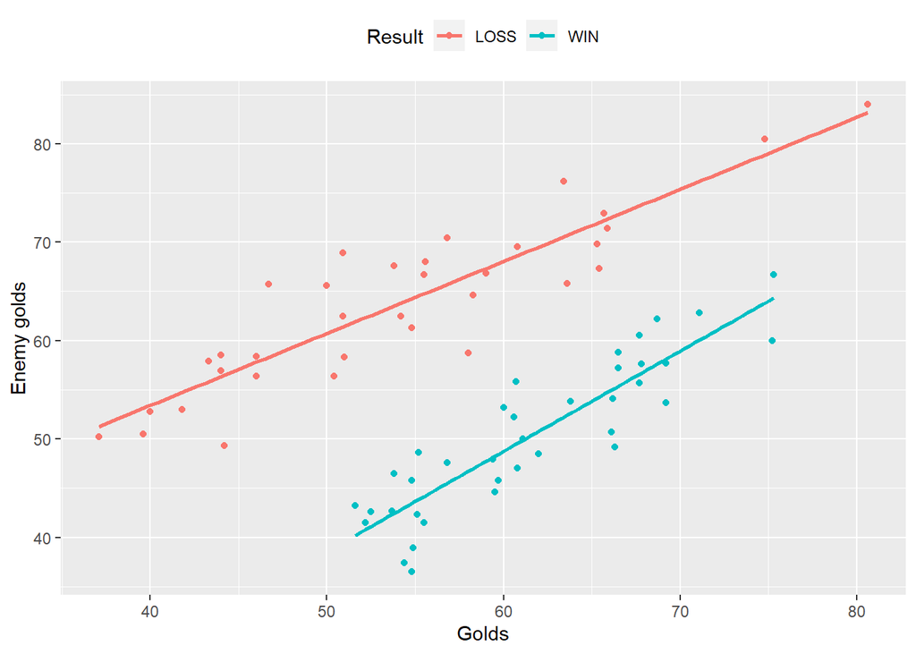

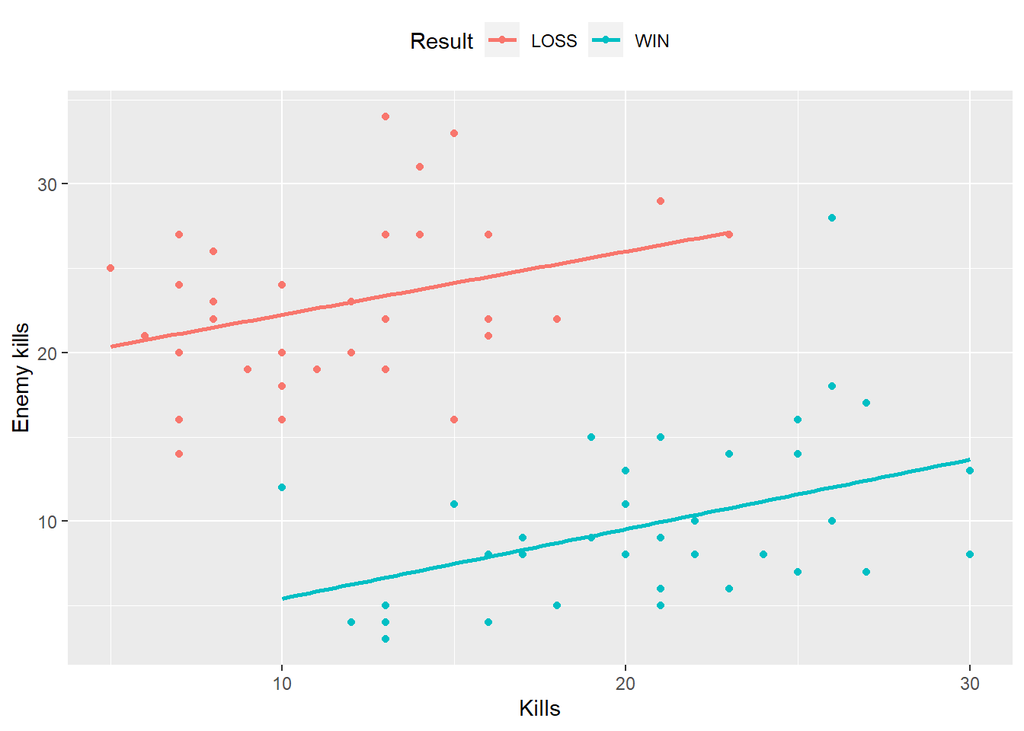

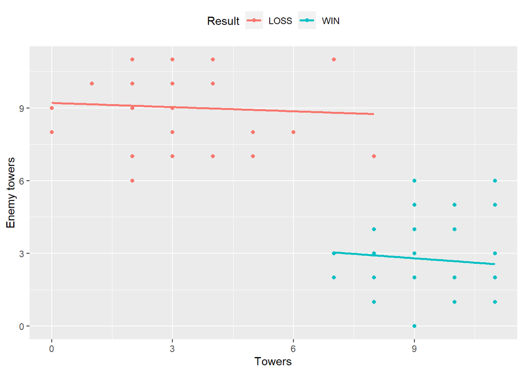

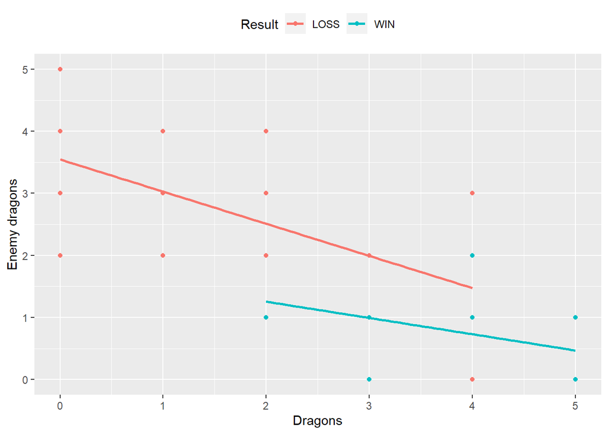

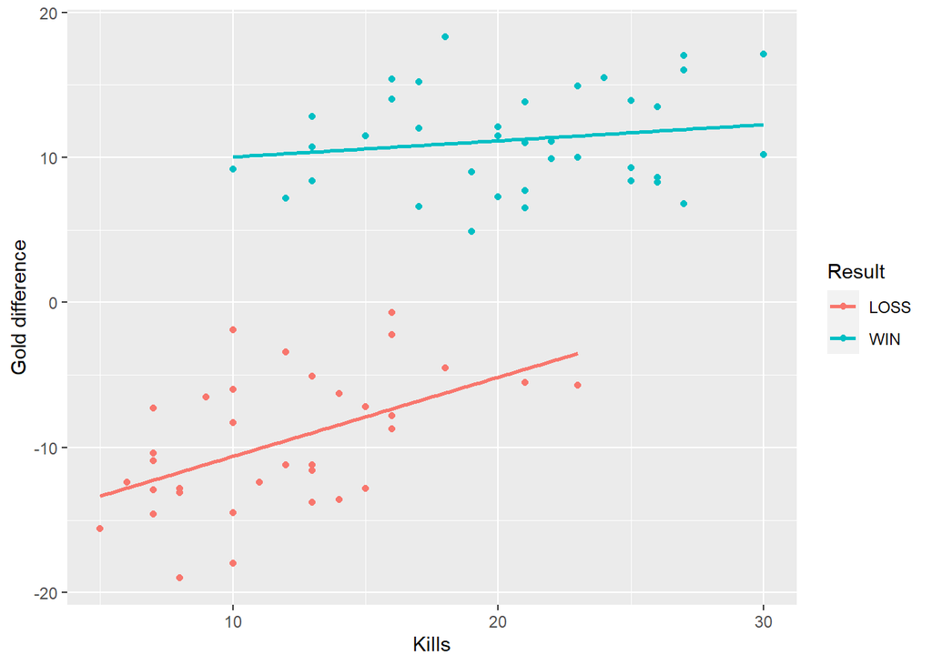

W drużynie Fnatic zależność między eliminacjami a różnicą w złocie zdaje się być najbardziej uporządkowana sposród omawianych drużyn. Zauważyć można że u jako jedynych we wszystkich przegranych meczach przegrywali w złocie a we wszystkich wygranych byli na prowadzeniu. Świadczyć to może o stabliności prowadzenia rozgrywki.

# Zestawienie między drużynami

Zestawienie tabelaryczne średnich wartości zdobywanych celów przez omawiane drużyny z podziałem na wynik meczu prezentuje się następująco:

Team

Logo

Result

Avg kills

Avg golds

Avg towers

Avg dragons

MAD

[figure not shown]

LOSS

9.6

55.4

3.8

1.4

WIN

20.1

64.8

9.7

2.9

RGE

[figure not shown]

LOSS

10.6

58.4

3.6

1.5

WIN

17.8

63.6

9.4

2.8

G2

[figure not shown]

LOSS

8.7

52.1

3.0

1.7

WIN

19.8

66.0

9.5

3.4

FNC

[figure not shown]

LOSS

11.8

54.0

3.2

1.8

WIN

20.7

61.5

9.4

3.5

Porównanie na wykresach słupkowych

### Eliminacje

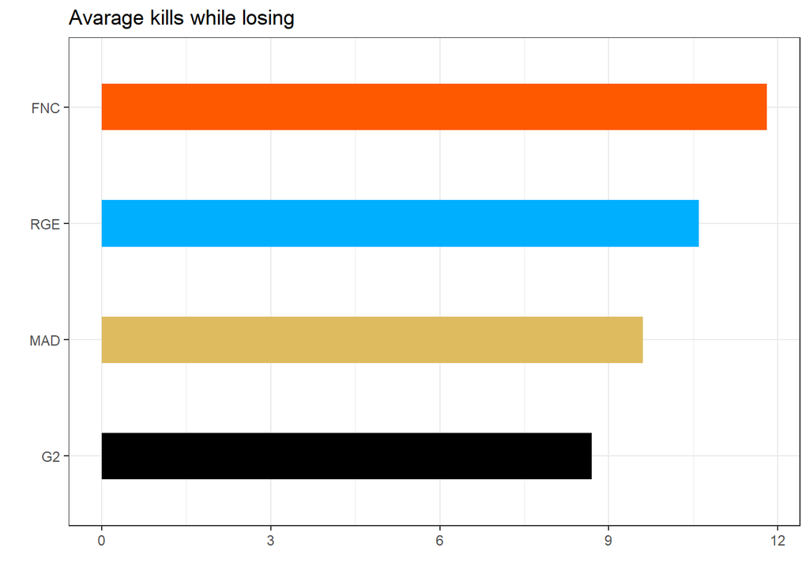

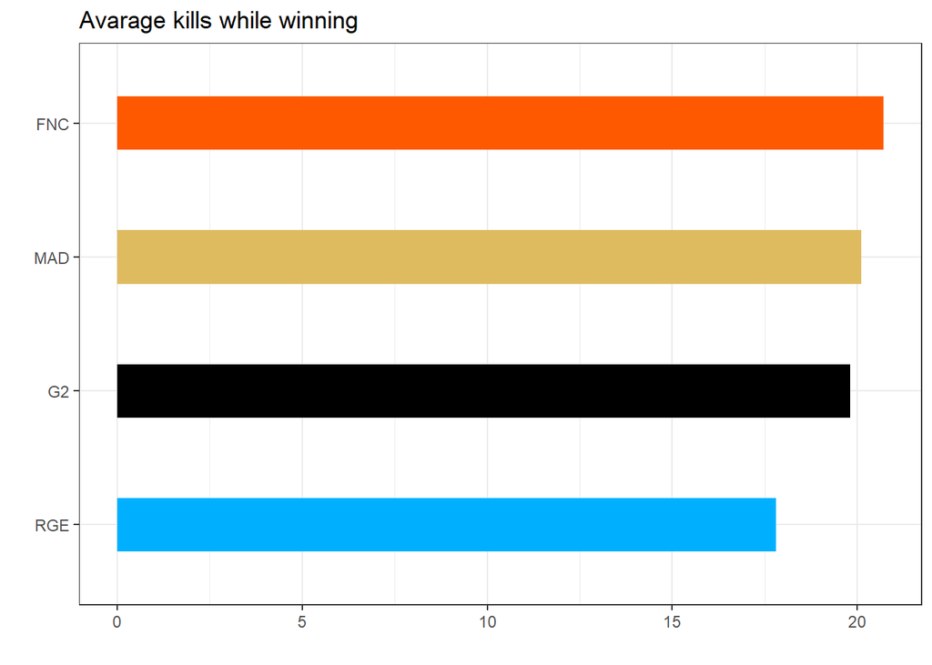

### Złoto

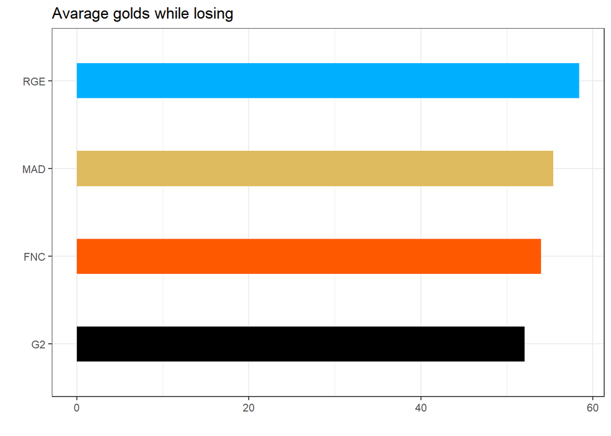

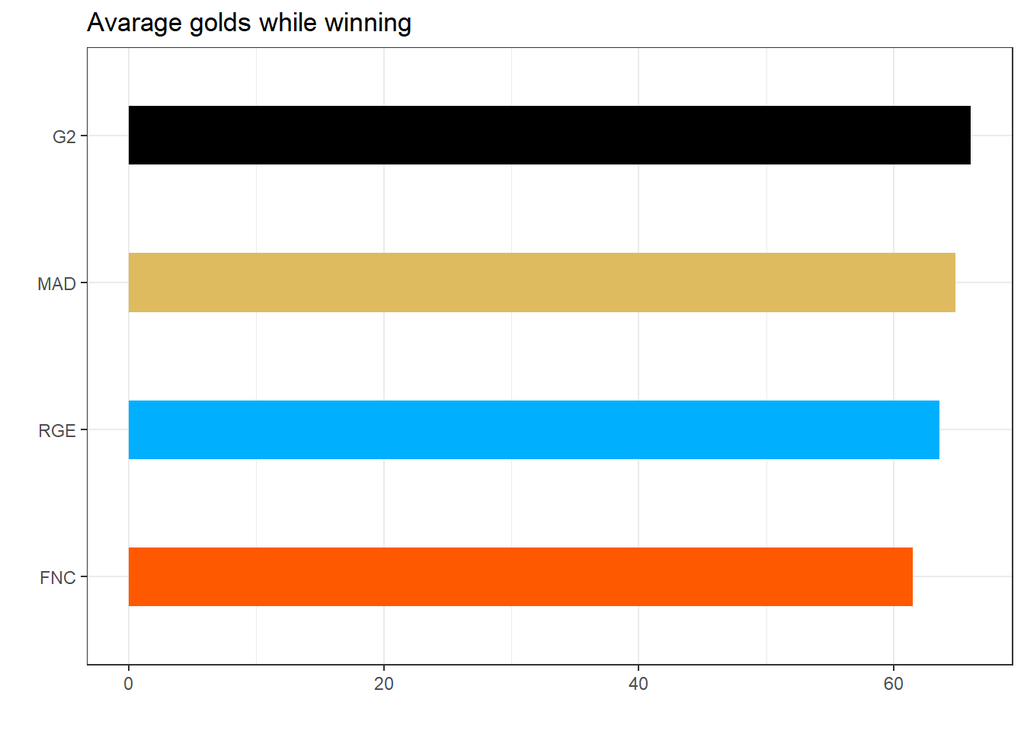

### Wieże

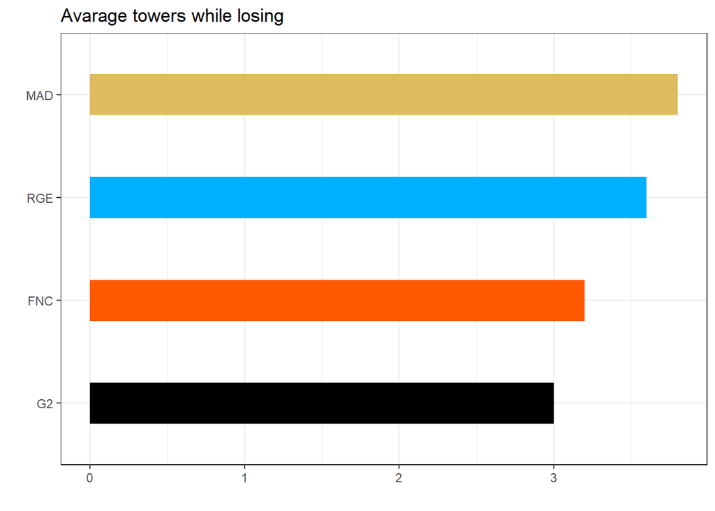

[figure not shown]

### Smoki

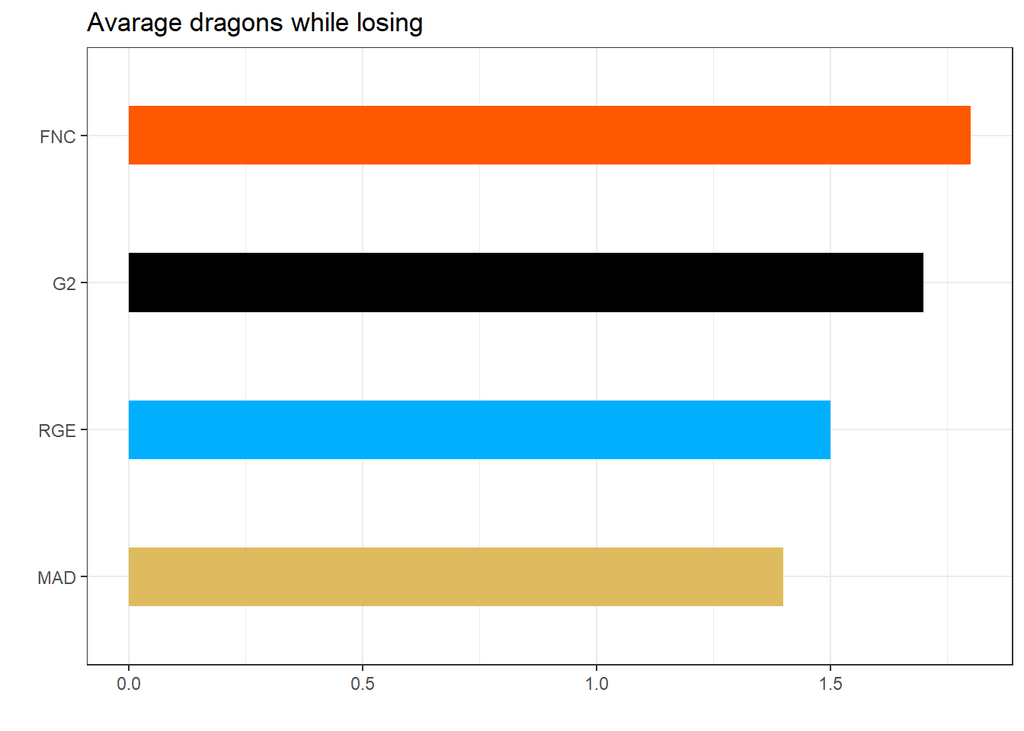

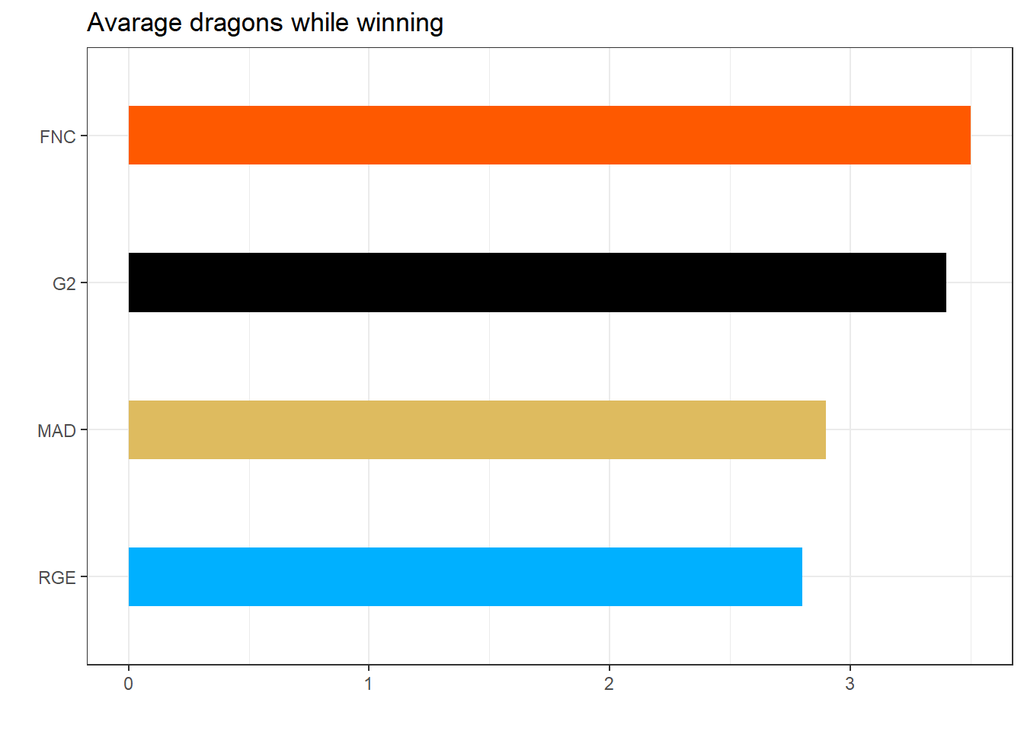

# Źródła

1. Dane pobrane ze strony Games of Legends - https://gol.gg/esports/home/
2. Dodatkowe informacje i grafiki - https://lol.fandom.com/wiki/League_of_Legends_Esports_Wiki